# 多元相关与回归分析及R的使用

shixiangzhou

2015年10月5日

# 变量间的关系分析

变量间的关系有两种：一种是平行关系，即两个或两个以上变量之间相互影响，另一种是依存关系，即一个变量的变化受另一个或几个变量的影响。

相关分析是研究呈平行关系的相关变量之间的关系，而回归分析是研究呈依存关系的相关变量之间的关系。

在一定价格条件下，商品销售额与销售量的依存关系。

1. 两变量线性相关系数的计算

$$\rho=\frac{cov(x,y)}{\sqrt{var(x)var(y)}}=\frac{\sigma_{xy}}{\sqrt{\sigma_x^2\sigma_y^2}}$$

在实际中我们通常要计算样本的线性相关系数(Peason相关系数)，计算公式如下：

$$r=\frac{s_{xy}}{\sqrt{s_x^2* s_y^2}}=\frac{l_{xy}}{\sqrt{l_{xx}*l_{yy}}}=\frac{\sum(x-\bar{x})(y-\bar{y})}{\sqrt{\sum(x-\bar{x})^2\sum(y-\bar{y})^2}}$$

**例题1** 身高与体重的相关关系分析，先计算离均差乘积和函数$l_{xy}$,和离均差平方和$l_{xx},l_{yy}$.

$$l_{xx}=556.9,l_{yy}=813,l_{xy}=645.5$$

$$r=\frac{l_{xy}}{\sqrt{l_{xx}*l_{yy}}}=0.9593$$

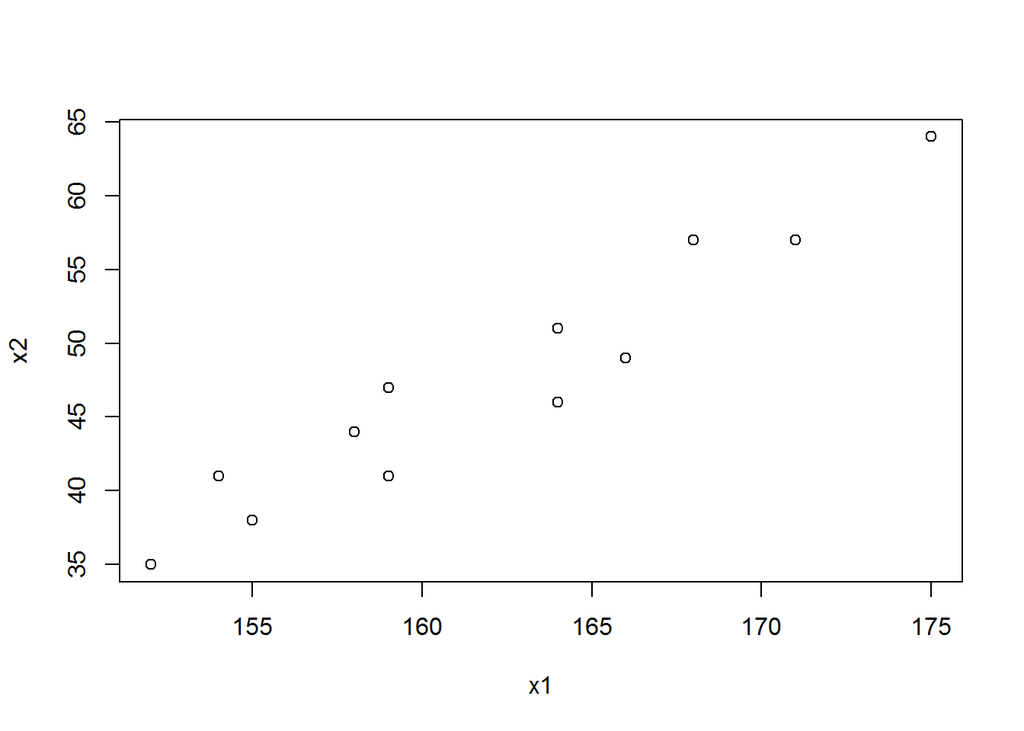

```r
x1=c(171,175,159,155,152,158,154,164,168,166,159,164)#身高
x2=c(57,64,41,38,35,44,41,51,57,49,47,46)#体重
plot(x1,x2)#做散点图
```

```r
lxy<-function(x,y){n=length(x);sum(x*y)-sum(x)*sum(y)/n}#建立离均差乘积和函数
lxy(x1,x1)#x1的离均差平方和
```

```
## [1] 556.9167
```

```r
lxy(x2,x2)#x1的离均差平方和
```

```
## [1] 813
```

```r
lxy(x1,x2)#x1的离均差乘积和
```

```
## [1] 645.5
```

```r
(r=lxy(x1,x2)/sqrt(lxy(x1,x1)*lxy(x2,x2)))#显示用离均差乘积和计算的相关系数
```

```
## [1] 0.9593031
```

```r
cor(x1,x2)#计算相关系数
```

```
## [1] 0.9593031
```

`cov(x, y = NULL, use = "everything", method = c("pearson", "kendall", "spearman"))`

```
method指的是计算相关系数的方法。
```

# 相关系数的假设检验

$r$与其他统计指标一样也有抽样误差，从同一总体抽取若干大小相同的样本，各样本的相关系数总有波动。要判断不等于0的$r$值是来自总体相关系数$\rho=0$的总体还是来自$\rho\ne 0$的总体，必须进行显著性检验。

$r$的显著性检验可以t检验法：

*建立检验假设，$H_0:\rho=0,H_1:\rho\ne 0(\alpha=0.05)$

*计算相关系数$r$的$t$值：
$$t_r=\frac{r-0}{\sqrt{\frac{1-r^2}{n-2}}}=10.74$$

```r
n=length(x1)#向量的长度
tr=r/sqrt((1-r^2)/(n-2))#相关系数假设检验t统计量
tr
```

```
## [1] 10.74298
```

*计算$t$值和$p$值：

```r
cor.test(x1,x2)#相关系数假设检验
```

```
##
##  Pearson's product-moment correlation
##
## data:  x1 and x2
## t = 10.743, df = 10, p-value = 8.21e-07
## alternative hypothesis: true correlation is not equal to 0
## 95 percent confidence interval:
##  0.8574875 0.9888163
## sample estimates:
##       cor
## 0.9593031
```

`cor.test(x, y, alternative = c(“two.sided”, “less”, “greater”),

```
     method = c("pearson", "kendall", "spearman"),

     exact = NULL, conf.level = 0.95, continuity = FALSE, ...)`
```

由于$p=8.21e-07<0.05$，故拒绝$H_0$，接受$H_1$,可认为该人群身高和体重呈正的线性关系。

相关系数的显著性与自由度有关。

# 一元线性回归的R计算

研究两个变量之间的依存关系，将变量区分出自变量和因变量，并研究确定自变量和因变量之间的具体关系的方程形式。分析中所形成的这种关系称为回归模型，其中以一条直线方程表明两变量依存关系的模型叫单变量(一元)线性回归模型。主要步骤包括： 建立回归模型，求解回归模型中的系数，对回归模型进行检验等。

## 一元线性回归模型的参数估计

直线方程模型为：$\hat{y}=a+bx$ $a,b$为待估参数，$x$为自变量的实际值，$b$也叫回归系数。

计算$a,b$常用最小二乘估计方法。

由散点图知道，虽然$x$与$y$间有直线趋势存在，但并不是一一对应的，每一个值$x_i$与对$y_i(i=1,2,\cdots,n)$用回归方程估计的$\hat{y_i}$值(即直线上的点)，或多或少存在一定的差距，这些差距用$(y_i-\hat{y_i})$来表示，称为估计的误差或残差(residual)。要使得回归方程比较“理想”，很自然会想到应该使得这些估计的误差尽量小一些，也就是使得估计误差的平方和
$$Q=\sum_{i=1}^n (y_i-\hat{y_i})^2=\sum_{i=1}^n[y_i-(a+bx_i)]^2$$
达到最小。对求关于的偏导数，并分别令其为0，可得：
$$b=\frac{\sum_{i=1}^n(x_i-\bar{x})(y_i-\bar{y})}{\sum_{i=1}^n(x_i-\bar{x})^2}=\frac{l_{xy}}{l_{xx}}$$
$$a=\bar{y}-b\bar{x}$$

```r
x=x1#自变量,数据来自例2.2
y=x2#因变量,数据来自例2.2
b=lxy(x,y)/lxy(x,x)#线性回归方程斜率
a=mean(y)-b*mean(x)#线性回归方程截距
c(a=a,b=b)#显示线性回归方程估计值
```

```
##          a          b
## -140.36436    1.15906
```

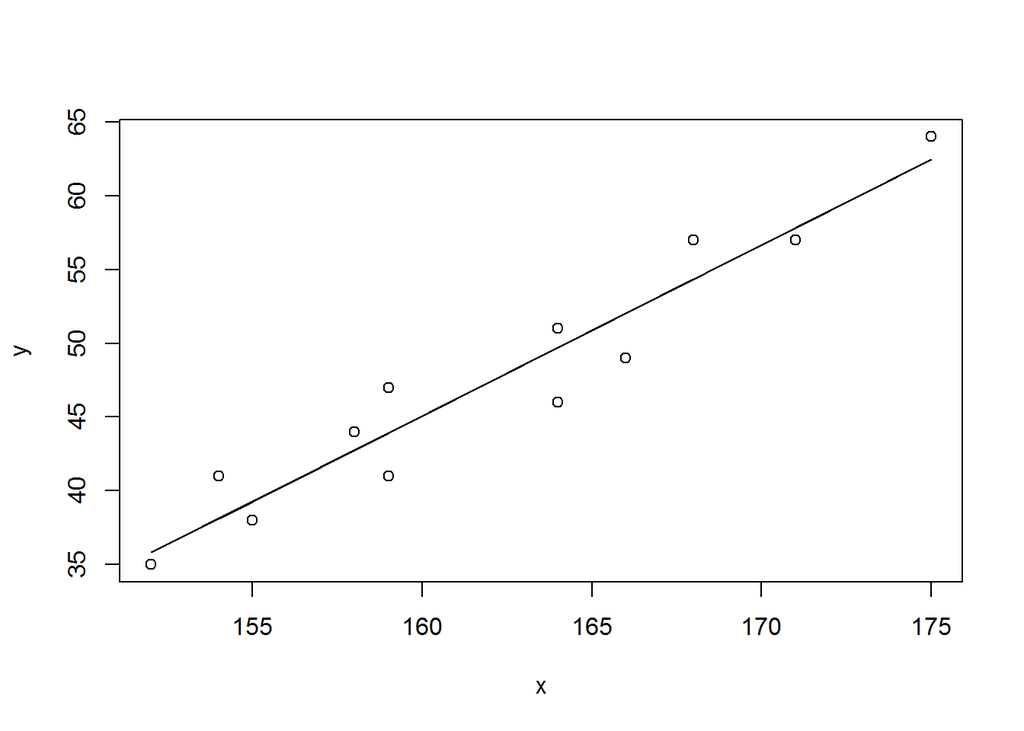

```r
plot(x,y)#做散点图
lines(x,a+b*x)#添加估计方程线
```

## 回归系数的假设检验

由样本资料建立回归方程的目的是对两变量的回归关系进行推断，也就是对总体回归方程做估计。由于抽样误差，样本回归系数$b$往往不会恰好等于总体回归系数$\beta$。如果总体回归系数$\beta=0$，那么当$\hat{y}$是常数，无论$x$如何变化，都不会影响$\hat{y}$，回归方程就没有意义。

当总体回归系数$\beta=0$时，由样本资料计算得到的样本回归系数$b$不一定为0，所以有必要对估计得到的样本回归系数$b$进行检验。检验一般用方差分析或$t$检验，两者的检验结果是等价的。方差分析主要是针对整个模型的，而$t$检验是关于回归系数的。

### 方差分析

经回归分析，因变量$y$实测值的离均差平方和为$SS_T=\sum_{i=1}^n(y_i-\bar{y})^2=l_{yy}$,被分解为两部分，第一部分为$SS_E=\sum_{i=1}^n(y_i-\hat{y})^2$，其本质是估计误差的平方和，这部分反映了这组实测值$y_i$扣除了$x$对$y$的影响后剩下的变异，另一部分为$SS_R=\sum_{i=1}^n(\hat{y_i}-\bar{y})^2$，反映了了$x$对$y$的线性影响，称为回归平方和或回归贡献，不难证明$SS_T=SS_R+SS_E$。

判断回归贡献是否有意义可以用方差分析进行检验，这时总变异的自由度为$df_T=n-1$,由于只有一个自变量，所以回归自由度$df_R=1$,误差自由度$df_E=df_T-df_R=n-2$,可分别计算回归均方与误差均方，进而得到$F$值。

$$MS_R=\frac{SS_R}{df_R},MS_E=\frac{SS_E}{df_E},F=\frac{MS_R}{MS_E}$$
$$SS_R=\sum_{i=1}^n(\hat{y_i}-\bar{y})^2=b\sum_{i=1}^n(y_i-\bar{y})(x_i-\bar{x})=bl_{xy}$$
$$SS_E=\sum_{i=1}^n(y_i-\hat{y_i})^2=\sum_{i=1}^n(y_i-\bar{y})^2-\sum_{i=1}^n(\hat{y_i}-\bar{y})^2$$

$H_0$:模型无意义，即$\beta=0$ $H_1$:模型有意义，即$\beta\ne 0$

```r
SST=lxy(y,y)#因变量的离均差平方和
SSR=b*lxy(x,y)#回归平方和
SSE=SST-SSR#误差平方和
MSR=SSR/1#回归均方
MSE=SSE/(n-2)#误差均方
F= MSR/MSE#F统计量
c(SST=SST,SSR=SSR,SSE=SSE,MSR=MSR,MSE=MSE,F=F)#显示结果
```

```
##        SST        SSR        SSE        MSR        MSE          F
## 813.000000 748.173425  64.826575 748.173425   6.482657 115.411531
```

### t检验

当$\beta=0$成立时，样本回归系数$b$服从正态分布，可用t检验法检验$b$是否有统计学意义。

检验统计量为：
$$t=\frac{b-\beta}{s_b}~t(n-2)$$
$$s_b=\frac{s_{y.x}}{\sqrt{\sum_{i=1}^n(y_i-\hat{y_i})^2}}=\frac{s_{y.x}}{\sqrt{l_{xx}}}$$
$$s_{y.x}=\sqrt{\frac{\sum_{i=1}^n(y_i-\hat{y_i})^2}{n-2}}=\sqrt{\frac{SS_E}{n-2}}=\sqrt{MS_E}$$

```r
sy.x=sqrt(MSE)#估计标准差
sb=sy.x/sqrt(lxy(x,x))#离均差平方和
t=b/sb#t统计量
ta=qt(1-0.05/2,n-2)#t分位数
c(sy.x=sy.x,sb=sb,t=t,ta=ta)#显示结果
```

```
##       sy.x         sb          t         ta
##  2.5461063  0.1078901 10.7429759  2.2281389
```

```
也可以用R自带的线性回归拟合函数：`lm(formula, ...)`
```

**例题2** 研究财政收入与税收的依存关系，1978-2008年我国共31年的税收($x$，百亿元)和财政收入($y$，百亿元)数据。分析变量间的依存关系。

1. 读入数据

```r
yx=read.table("clipboard",header=T)#加载
```

2. 拟合模型

```r
fm=lm(y~x,data=yx)#一元线性回归模型
fm
```

```
##
## Call:
## lm(formula = y ~ x, data = yx)
##
## Coefficients:
## (Intercept)            x
##      -1.197        1.116
```

3. 做回归直线

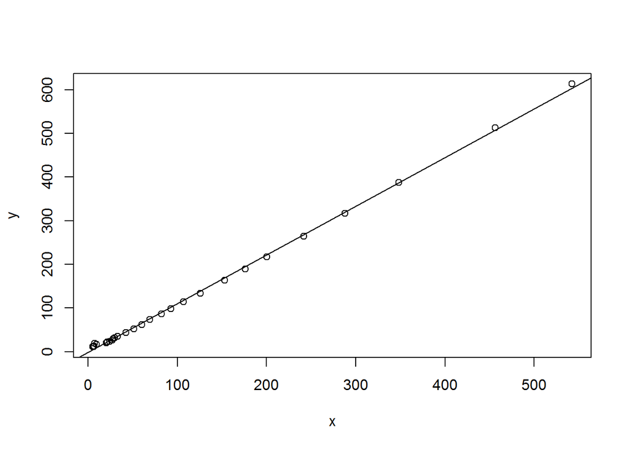

```r
plot(y~x,data=yx)#做散点图
abline(fm)#添加回归线
```

4. 回归方程的检验
5. 模型方差分析ANOVA

```r
anova(fm)#模型方差分析
```

```
## Analysis of Variance Table
##
## Response: y
##           Df Sum Sq Mean Sq F value    Pr(>F)
## x          1 712077  712077   27428 < 2.2e-16 ***
## Residuals 29    753      26
## ---
## Signif. codes:  0 '***' 0.001 '**' 0.01 '*' 0.05 '.' 0.1 ' ' 1
```

由于$p<0.5$拒绝$H_0$,即回归系数有统计学意义。

2. 回归系数的$t$检验

```r
summary(fm)#回归系数t检验
```

```
##
## Call:
## lm(formula = y ~ x, data = yx)
##
## Residuals:
##    Min     1Q Median     3Q    Max
## -6.630 -3.692 -1.535  5.338 11.432
##
## Coefficients:
##             Estimate Std. Error t value Pr(>|t|)
## (Intercept) -1.19656    1.16125   -1.03    0.311
## x            1.11623    0.00674  165.61   <2e-16 ***
## ---
## Signif. codes:  0 '***' 0.001 '**' 0.01 '*' 0.05 '.' 0.1 ' ' 1
##
## Residual standard error: 5.095 on 29 degrees of freedom
## Multiple R-squared:  0.9989, Adjusted R-squared:  0.9989
## F-statistic: 2.743e+04 on 1 and 29 DF,  p-value: < 2.2e-16
```

可见当只有一个自变量时，方差分析与t检验法一致，但在多元分析中，方差分析和t检验的结果并不一定等价。

如有错误请联系 [e-mail]:shixiangbupt@qq.com.